# Part II - PISA 2012 Exploration

## Dataset Overview

The database consists of questionnaire answers and test results of almost half a million children born in 1996, the questionnaire was conducted in 2012. The questionnaire was collected from a random sample represented in 68 different countries that requested to be included in the test. As far as I understand, the database was taken from the PISA website and the udacity team converted it from SPSS to CSV.

## Total Mean Score by Country

- PISA measures students' abilities in three categories - math, science, and reading.
- For the purpose of this analysis, I chose to simplify the data and create an Total Mean Score for each student.
- In the Visualization below we can see all the countries (except micro-countries) that participated in the study and the Total Mean Score of the country's students.

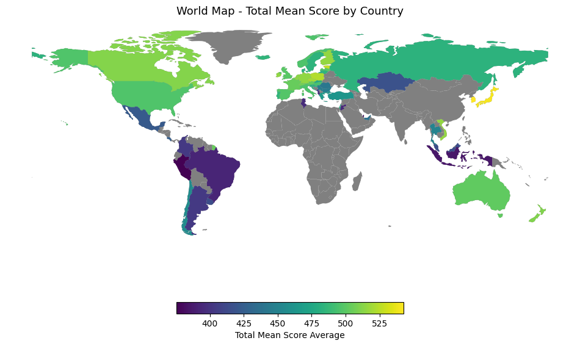

## Total Mean Score by Country in a simple bar-plot

To easily see the distribution of scores between the countries, a simple bar plot is attached below that includes all the countries that participated in the study and the global average

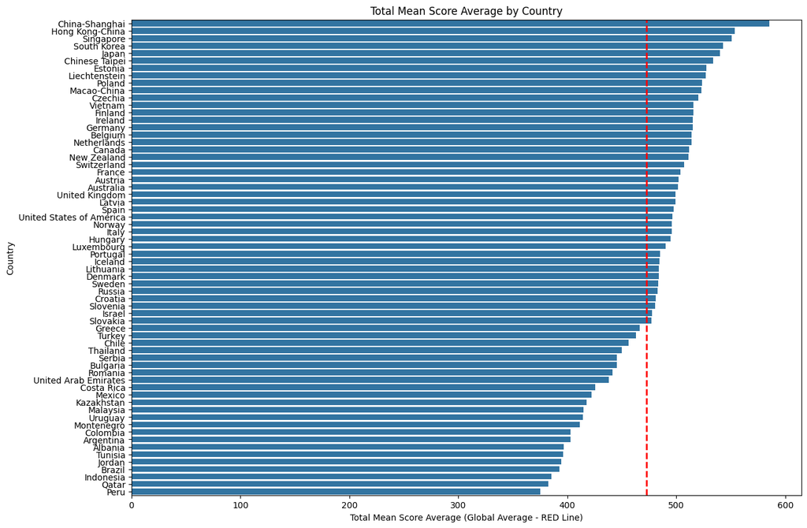

## Total Mean Score in relation ESCS

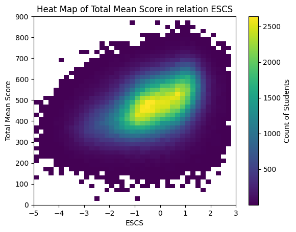

## Correlation Strength - ESCS Level VS Total Mean Score of Student by Country

In the Visualization below we can see the strength of the relationship between the socio-economic status (ESCS) and the student's grade by country. The stronger the correlation, the more significant the student's socioeconomic status is as a predictor of his Total Mean Score.

- 0 indicates that there is no correlation, 1 indicates that there is a complete correlation.

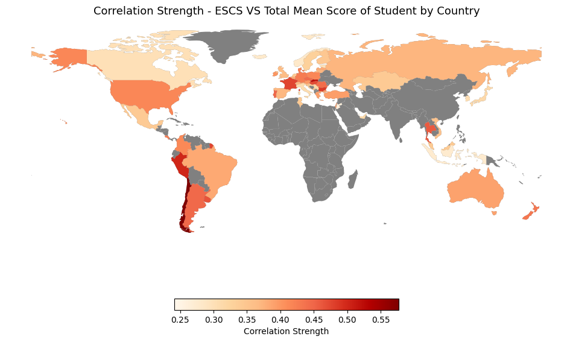

## Correlation Strength - ESCS Level VS Total Mean Score of Student by Country in a bar-plot

It is my opinion that the strength of the correlation between the socioeconomic index and the student's grades is a relatively good assessment, even if a little superficial, of the level of equality in the education system in different countries. The smaller the correlation, it can be assumed that the education system in the country provides the same level of education to all students. In order to confirm my thesis, a comparison is needed here between the research countries over the years and an examination of the trends.

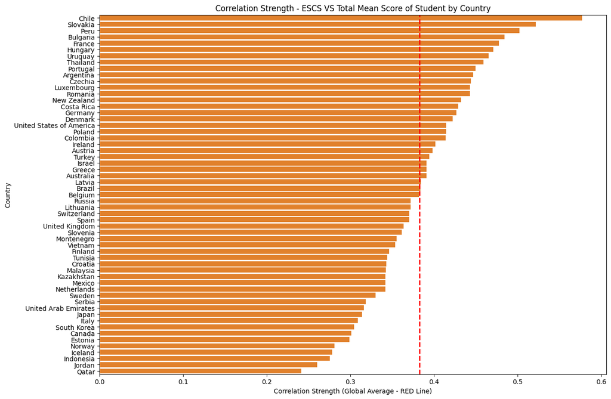

## Key Insights

- Educational systems around the world see different importance in the right to equality in education (educational justice). Creating a test to stand for equality in the system over time and its effects on student achievement can give us many insights and help in the public discourse and data-based policy promotion.
- The PISA database is an amazing tool for international comparison of the various education systems. Caution is required and it is dangerous to draw conclusions from measurements of only one year, yet the examination of the trends throughout the years of the study can greatly contribute to the participating countries and the field of education research.